# Thailand Medical Record

August 10, 2018

## 2014

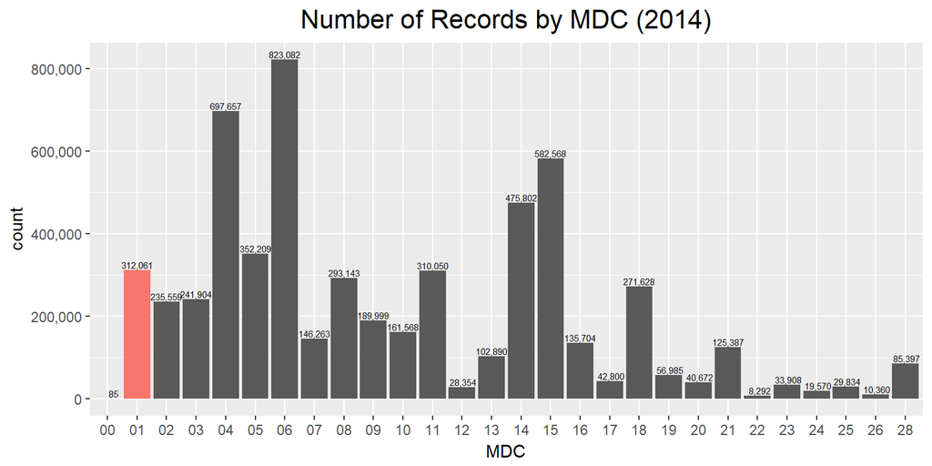

มีการบันทึกข้อมูลผู้ป่วยในกลุ่มโรคทางระบบประสาท 312,061 ครั้ง จากทั้งหมด 5,813,731 ครั้ง

## 2014

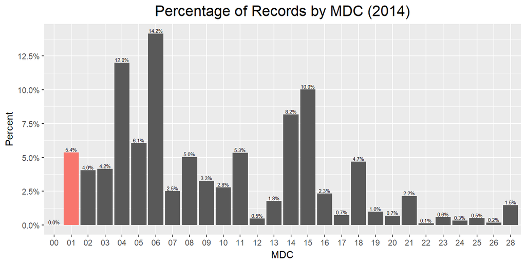

หรือคิดเป็น 5.4% ของการบันทึกทั้งหมด

## 2014

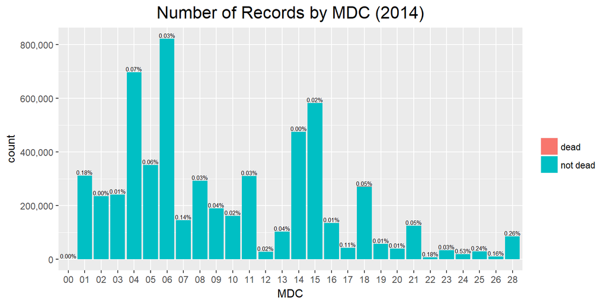

## 2014

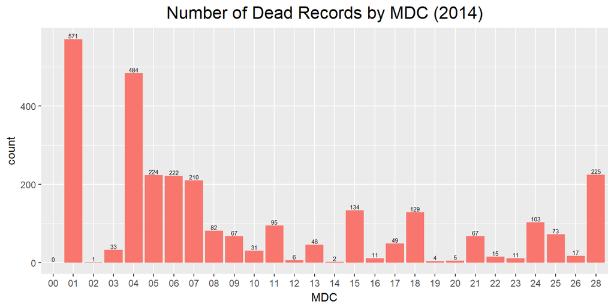

มีการบันทึกข้อมูลผู้ป่วยที่เสียชีวิตในกลุ่มโรคทางระบบประสาท 571 ครั้ง ซึ่งสูงที่สุดเมื่อเทียบกับกลุ่มโรคตามระบบร่างกายอื่นๆ

## 2014

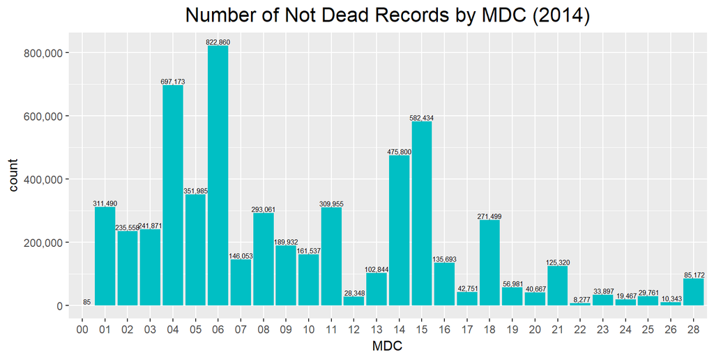

ในขณะที่การบันทึกข้อมูลผู้ป่วยที่ไม่เสียชีวิตนั้น กลุ่มโรคทางระบบประสาทถูกจัดอยู่อันดับที่ 6 เมื่อนับจากมากไปน้อย และมีจำนวน 311,490 ครั้ง

## 2014

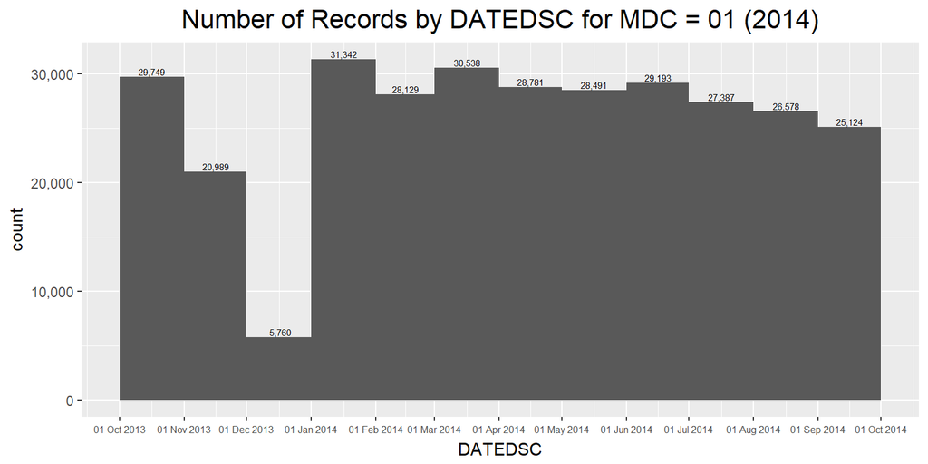

สำหรับข้อมูลปี 2014 และเป็นของกลุ่มโรคทางระบบประสาท พบว่าจะบันทึกตามวันที่จำหน่ายผู้ป่วยออกจากโรงพยาบาล (DATEDSC) ซึ่งพบวันที่ในช่วงตั้งแต่ 1 ตุลาคม 2013 ถึง 30 กันยายน 2014 และพบว่ามีการจำหน่ายผู้ป่วยออกจากโรงพยาบาลในเดือนธันวาคมน้อยที่สุด

## 2014

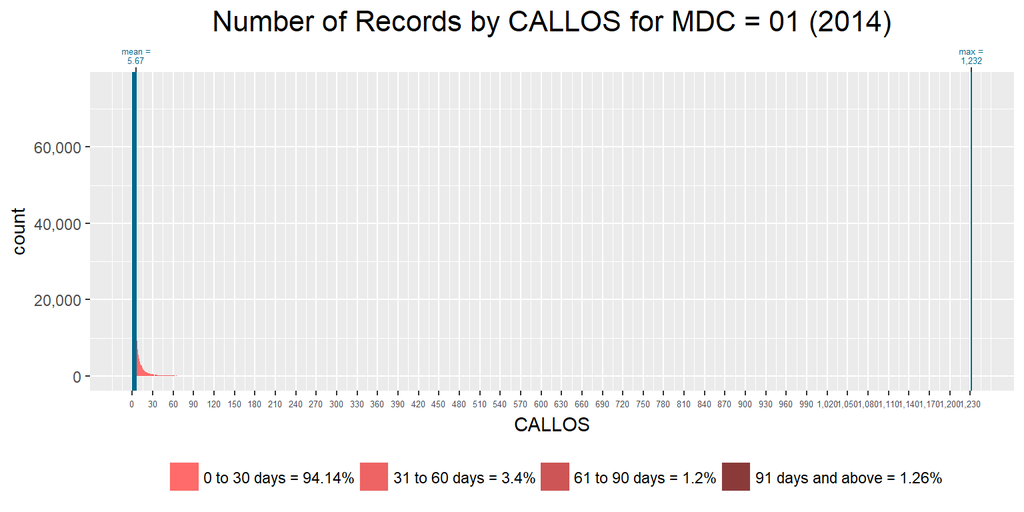

สำหรับจำนวนวันนอนในโรงพยาบาลแบบยังไม่หักจำนวนวันลากลับบ้านในกลุ่มโรคทางระบบประสาท ผู้ป่วยส่วนใหญ่จะนอนไม่เกิน 1 เดือน คิดเป็นสัดส่วนอยู่ที่ 94.14% ค่าเฉลี่ยจำนวนวันนอนเท่ากับ 5.67 วัน และ จำนวนวันนอนสูงสุดเท่ากับ 1,232 วัน

## 2014

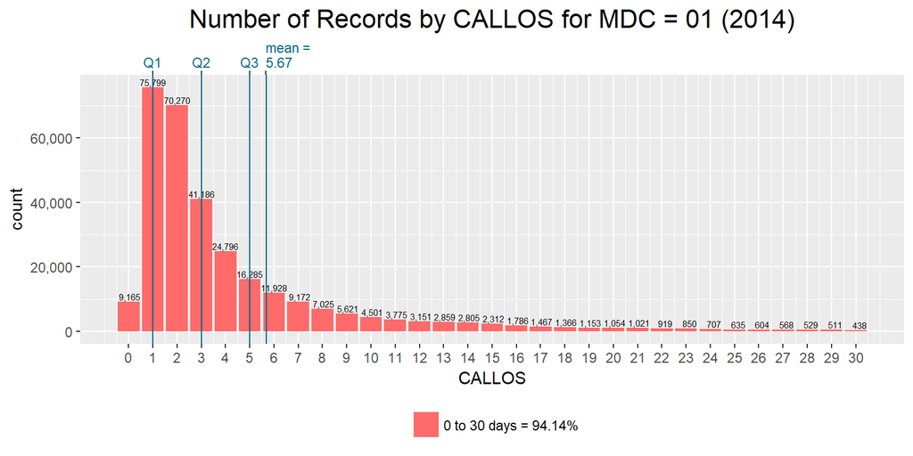

พบว่ามีการบันทึกจำนวนวันนอน 1 วัน สูงที่สุดที่ 75,799 ครั้ง และพบว่า 25% ของการบันทึกมีจำนวนวันนอนไม่เกิน 1 วัน 50% ของการบันทึกมีจำนวนวันนอนไม่เกิน 3 วัน 75% ของการบันทึกมีจำนวนวันนอนไม่เกิน 5 วัน

## 2014

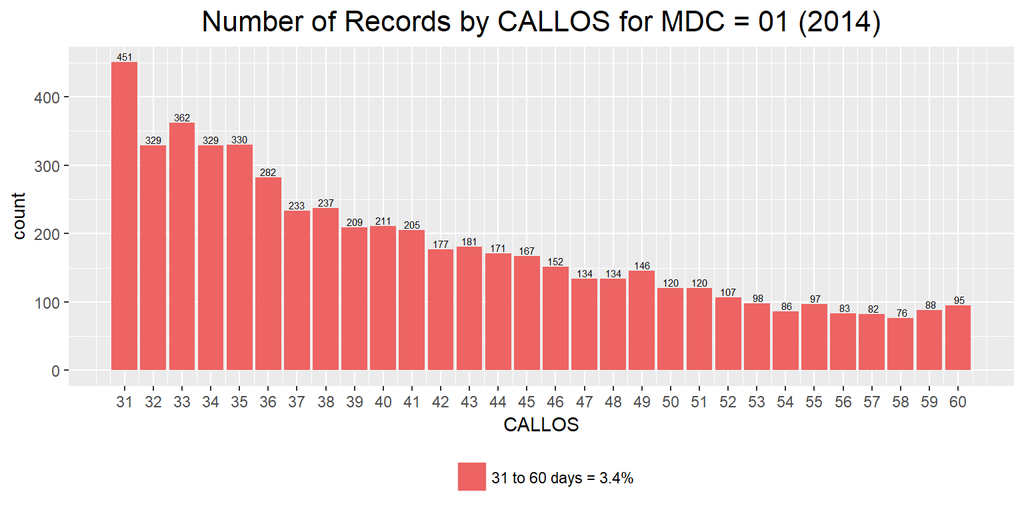

การบันทึกจำนวนวันนอนตั้งแต่ 31 วัน ถึง 60 วัน ลดลงเรื่อยๆ

## 2014

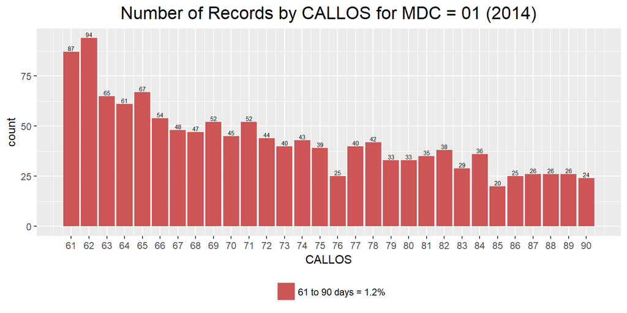

การบันทึกจำนวนวันนอนตั้งแต่ 61 วัน ถึง 90 วัน ลดลงเรื่อยๆ

## 2014

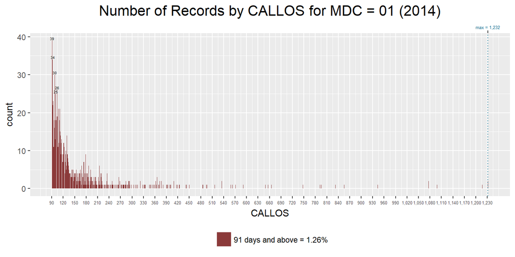

การบันทึกจำนวนวันนอนที่ 91 วันขึ้นไป ลดลงเรื่อยๆ และสิ้นสุดที่จำนวนวันนอนเท่ากับ 1,232 วัน ซึ่งมีการบันทึกอยู่ 2 ครั้ง

## 2014

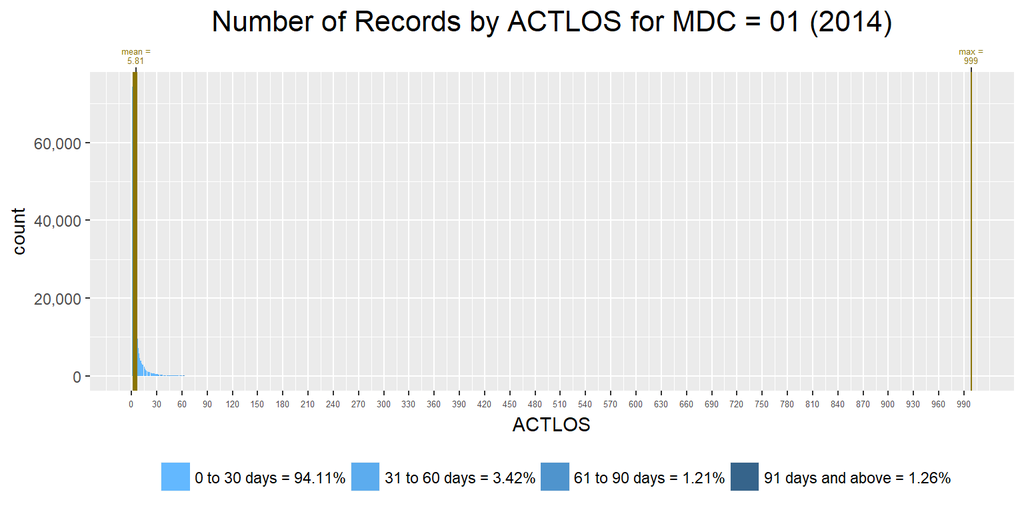

สำหรับจำนวนวันนอนในโรงพยาบาลแบบหักจำนวนวันลากลับบ้านในกลุ่มโรคทางระบบประสาท ผู้ป่วยส่วนใหญ่จะนอนไม่เกิน 1 เดือน คิดเป็นสัดส่วนอยู่ที่ 94.11% ค่าเฉลี่ยจำนวนวันนอนเท่ากับ 5.81 วัน และ จำนวนวันนอนสูงสุดเท่ากับ 999 วัน

## 2014

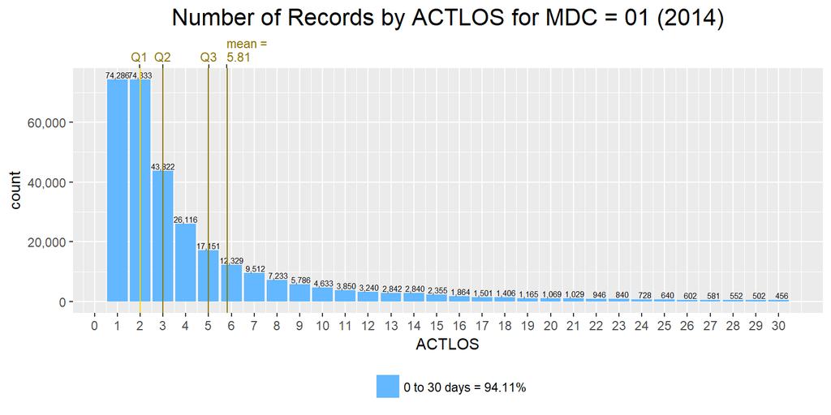

พบว่ามีการบันทึกจำนวนวันนอน 1 วัน และ 2 วัน พอๆกันที่ 74,286 วัน และ 74,333 วัน ตามลำดับ และพบว่า 25% ของการบันทึกมีจำนวนวันนอนไม่เกิน 2 วัน 50% ของการบันทึกมีจำนวนวันนอนไม่เกิน 3 วัน 75% ของการบันทึกมีจำนวนวันนอนไม่เกิน 5 วัน

## 2014

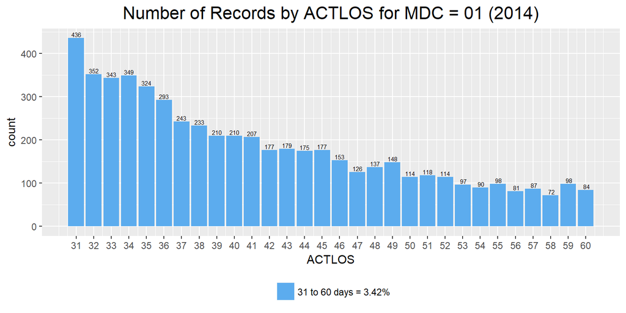

การบันทึกจำนวนวันนอนตั้งแต่ 31 วัน ถึง 60 วัน ลดลงเรื่อยๆ

## 2014

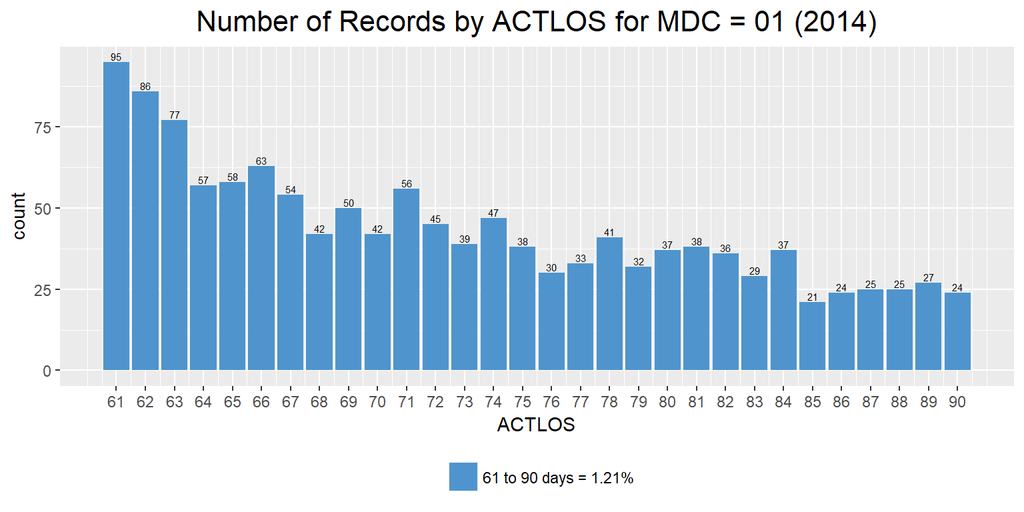

การบันทึกจำนวนวันนอนตั้งแต่ 61 วัน ถึง 90 วัน ลดลงเรื่อยๆ

## 2014

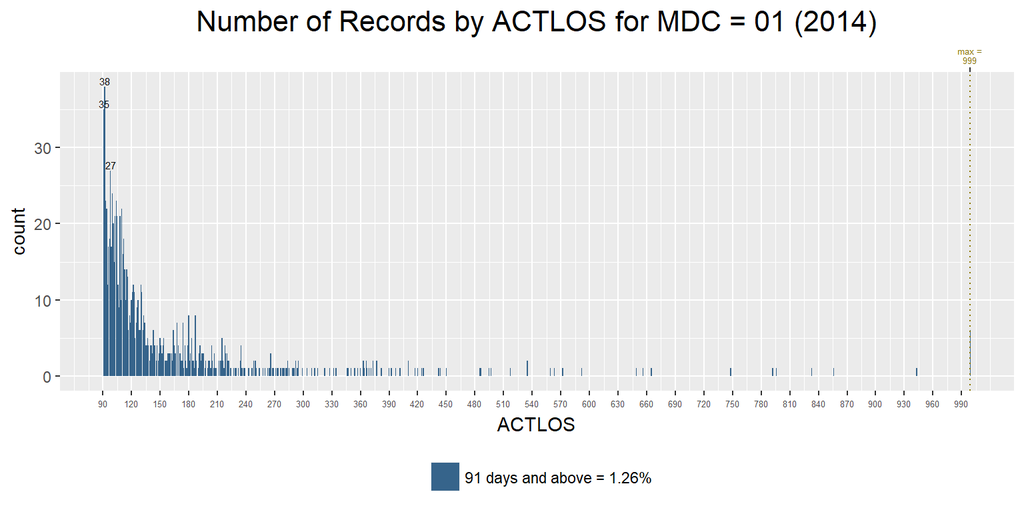

การบันทึกจำนวนวันนอนที่ 91 วันขึ้นไป ลดลงเรื่อยๆ และสิ้นสุดที่จำนวนวันนอนเท่ากับ 999 วัน ซึ่งมีการบันทึกอยู่ 6 ครั้ง

## 2014

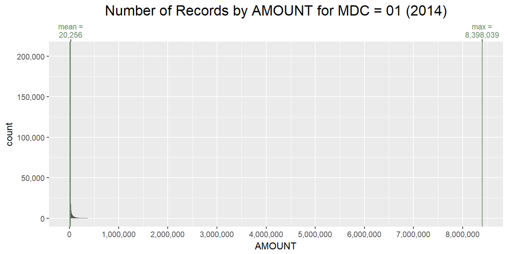

ฮิสโตแกรมแสดงค่าใช้จ่ายสำหรับกลุ่มโรคทางระบบประสาท ซึ่งแต่ละช่วงมีความกว้าง 10,000 บาท พบว่า ค่าใช้จ่ายเฉลี่ยเท่ากับ 20,256 บาท และค่าใช้จ่ายสูงสุดเท่ากับ 8,398,039 บาท

## 2014

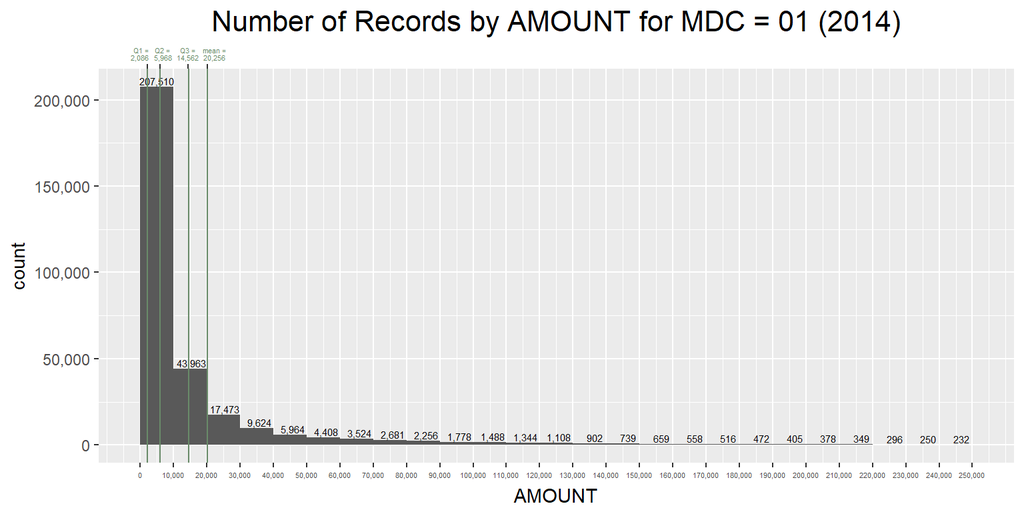

พบว่า 25% ของการบันทึกมีค่าใช้จ่ายไม่เกิน 2,086 บาท 50% ของการบันทึกมีค่าใช้จ่าย 5,968 บาท 75 % ของการบันทึกมีค่าใช้จ่าย 14,562 บาท และ 80.78% ของการบันทึกมีค่าใช้จ่ายไม่เกินค่าเฉลี่ยของค่าใช้จ่าย ซึ่งเท่ากับ 20,256 บาท

## 2014